# Study of Bees

Cynthia Anstey

12 November, 2023

**Week 7**  
Mini Assignment

1. R code explores the Honeybees and Neonic Pesticides data. https://www.kaggle.com/datasets/kevinzmith/honey-with-neonic-pesticide.
2. Use graphs (e.g. plot(), hist(), factor(), ggplot()) to visualize the data.
3. Make sure you include inline comments so that the reader knows what each line of your R code does.
4. Include comments or text with an explanation of your findings or what you thought you might find versus what you did find.
5. Remember there is at least one dependent and independent variable

.

```r
# Start by reading in the necessary libraries
library(tidyverse)
library(lubridate)
library(stringr)
# I could save the answer to another dataframe or use a special two-way pipe from the
# TidyVerse package magrittr
library(magrittr)
library(nFactors)
require(nFactors)
library(scales)
# tidyverse to help me read
# Lubridate for date related functions.
# stringr to help with columns.
# Called tidyverse, lubridate, and stringer.
# shortcut is control enter.
# Read the data set using the base R function read.csv.
# Set header = TRUE because the first line of the CSV file is a header line.
```

```r
# Read in the data, no need to skip rows.
library(readr)
HoneyBees <- read_csv("C:/Users/crook/OneDrive/Desktop/Data Exploration/Data/HoneyBees.csv")
```

## Question

What is the initial impressions of the data? The state is duplicated. It is both spelled out and abbreviated. Researched Kaggle to get the metadata so I can see what it spells out in each column.

## Reading and Visualizing the Data

How many colonies were counted by state by year Region by year? How much did those colonies produce by state by year Region by year? Did the number of colonies increase or decrease as the amount of pesticides increased or decreased?

```r
spec(HoneyBees)
```

```r
str(HoneyBees)
```

```
spc_tbl_ [825 × 16] (S3: spec_tbl_df/tbl_df/tbl/data.frame)
 $ state        : chr [1:825] "AL" "AL" "AL" "AL" ...
 $ numcol       : num [1:825] 11000 11000 12000 12000 13000 13000 14000 16000 16000 17000 ...
 $ yieldpercol  : num [1:825] 56 72 86 87 66 82 73 71 78 68 ...
 $ totalprod    : num [1:825] 616000 792000 1032000 1044000 858000 ...
 $ stocks       : num [1:825] 209000 230000 103000 282000 266000 43000 235000 159000 187000 185000 ...
 $ priceperlb   : num [1:825] 1.49 1.21 1.18 1.41 1.02 1.24 0.72 0.72 0.59 0.56 ...
 $ prodvalue    : num [1:825] 918000 958000 1218000 1472000 875000 ...
 $ year         : num [1:825] 2007 2006 2002 2004 2005 ...
 $ StateName    : chr [1:825] "Alabama" "Alabama" "Alabama" "Alabama" ...
 $ Region       : chr [1:825] "South" "South" "South" "South" ...
 $ nCLOTHIANIDIN: num [1:825] 7696 680 0 2676 1504 ...
 $ nIMIDACLOPRID: num [1:825] 3258 4230 1179 1324 994 ...
 $ nTHIAMETHOXAM: num [1:825] 4150 5372 840 3864 5494 ...
 $ nACETAMIPRID : num [1:825] 0 0 0 0 0 0 0 0 0 0 ...
 $ nTHIACLOPRID : num [1:825] 0 0 0 0 0 0 0 0 0 0 ...
 $ nAllNeonic   : num [1:825] 15104 10282 2019 7864 7992 ...
 - attr(*, "spec")=
  .. cols(
  ..   state = col_character(),
  ..   numcol = col_double(),
  ..   yieldpercol = col_double(),
  ..   totalprod = col_double(),
  ..   stocks = col_double(),
  ..   priceperlb = col_double(),
  ..   prodvalue = col_double(),
  ..   year = col_double(),
  ..   StateName = col_character(),
  ..   Region = col_character(),
  ..   nCLOTHIANIDIN = col_double(),
  ..   nIMIDACLOPRID = col_double(),
  ..   nTHIAMETHOXAM = col_double(),
  ..   nACETAMIPRID = col_double(),
  ..   nTHIACLOPRID = col_double(),
  ..   nAllNeonic = col_double()
  .. )
 - attr(*, "problems")=<externalptr>
```

I created a tibble so I can try to aggregate values.

```r
tibble(HoneyBees)
```

| state | numcol | yieldpercol | totalprod | stocks | priceperlb | prodvalue | year | StateName | Region | nCLOTHIANIDIN | nIMIDACLOPRID | nTHIAMETHOXAM | nACETAMIPRID | nTHIACLOPRID | nAllNeonic |
| --- | --- | --- | --- | --- | --- | --- | --- | --- | --- | --- | --- | --- | --- | --- | --- |
| AL | 11000 | 56 | 616000 | 209000 | 1.49 | 918000 | 2007 | Alabama | South | 7696.2 | 3258.1 | 4149.6 | 0.0 | 0.0 | 15103.9 |
| AL | 11000 | 72 | 792000 | 230000 | 1.21 | 958000 | 2006 | Alabama | South | 680.0 | 4230.2 | 5371.6 | 0.0 | 0.0 | 10281.8 |
| AL | 12000 | 86 | 1032000 | 103000 | 1.18 | 1218000 | 2002 | Alabama | South | 0.0 | 1178.8 | 840.4 | 0.0 | 0.0 | 2019.2 |
| AL | 12000 | 87 | 1044000 | 282000 | 1.41 | 1472000 | 2004 | Alabama | South | 2676.4 | 1323.9 | 3863.9 | 0.0 | 0.0 | 7864.2 |
| AL | 13000 | 66 | 858000 | 266000 | 1.02 | 875000 | 2005 | Alabama | South | 1503.6 | 994.5 | 5493.9 | 0.0 | 0.0 | 7992.0 |
| AL | 13000 | 82 | 1066000 | 43000 | 1.24 | 1322000 | 2003 | Alabama | South | 0.0 | 668.3 | 591.7 | 0.0 | 0.0 | 1260.0 |
| AL | 14000 | 73 | 1022000 | 235000 | 0.72 | 736000 | 2001 | Alabama | South | 0.0 | 1490.8 | 0.0 | 0.0 | 0.0 | 1490.8 |
| AL | 16000 | 71 | 1136000 | 159000 | 0.72 | 818000 | 1998 | Alabama | South | 0.0 | 1836.3 | 0.0 | 0.0 | 0.0 | 1836.3 |
| AL | 16000 | 78 | 1248000 | 187000 | 0.59 | 736000 | 2000 | Alabama | South | 0.0 | 1499.2 | 0.0 | 0.0 | 0.0 | 1499.2 |
| AL | 17000 | 68 | 1156000 | 185000 | 0.56 | 647000 | 1999 | Alabama | South | 0.0 | 1251.2 | 0.0 | 0.0 | 0.0 | 1251.2 |

[output cut: 815 more lines]

Below gives us a summary of Regions showing the total number of colonies and the total yield.

```r
HoneyBees %>% group_by(Region) %>%
summarise(sum(numcol),
          sum(yieldpercol))
```

| Region | sum(numcol) | sum(yieldpercol) |
| --- | --- | --- |
| Midwest | 20974000 | 15740 |
| Northeast | 2116000 | 4953 |
| South | 10281000 | 16023 |
| West | 17688000 | 12965 |

```r
NA
```

I used group by to calculate the average price per pound in all regions.

```r
HoneyBees %>% group_by(Region) %>%
summarise(avg_price = mean(priceperlb))
```

| Region | avg_price |
| --- | --- |
| Midwest | 1.708083 |
| Northeast | 2.109000 |
| South | 1.924672 |
| West | 1.464248 |

```r
NA
```

I used group by to calculate the average price per pound per year for each regions.

```r
HoneyBees %>% group_by(year, Region) %>%
summarise(avg_price = mean(priceperlb))
```

| year | Region | avg_price |
| --- | --- | --- |
| 1998 | Midwest | 0.7800000 |
| 1998 | Northeast | 0.7600000 |
| 1998 | South | 0.9528571 |
| 1998 | West | 0.7754545 |
| 1999 | Midwest | 0.7466667 |
| 1999 | Northeast | 0.6900000 |
| 1999 | South | 0.9521429 |
| 1999 | West | 0.7309091 |
| 2000 | Midwest | 0.7308333 |
| 2000 | Northeast | 0.6700000 |

[output cut: 66 more lines]

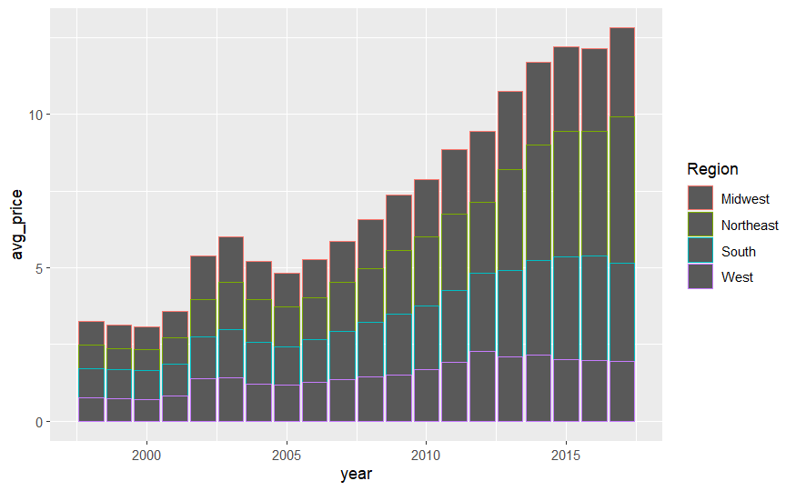

```r
HoneyBees %>% group_by(Region, year) %>%
summarise(avg_price = mean(priceperlb)) %>%
ggplot(aes(x = year, col=Region, y = avg_price)) +
geom_col(position = "stack")
```

the following summary functions shows me that we have less data from the Northeast.

```r
sel_data<-na.omit(HoneyBees[,grep("Region",colnames(HoneyBees))])
```

```r
summary.factor(sel_data)
```

```
  Midwest Northeast     South      West
      240       100       259       226
```

I thought maybe it was a good idea to count the number of States. I expanded the grep statement to show me the rows per each state. I noticed I am missing NH, RI, and CT. This might explain why the NorthEast numbers are so low.

```r
sel_data2<-na.omit(HoneyBees[,grep("StateName",colnames(HoneyBees))])
```

```r
summary.factor(sel_data2)
```

```
       Alabama        Arizona       Arkansas     California       Colorado        Florida
            20             20             20             20             20             20
       Georgia         Hawaii          Idaho       Illinois        Indiana           Iowa
            20             20             20             20             20             20
        Kansas       Kentucky      Louisiana          Maine       Maryland       Michigan
            20             20             20             20              6             20
     Minnesota    Mississippi       Missouri        Montana       Nebraska         Nevada
            20             20             20             20             20             11
    New Jersey     New Mexico       New York North Carolina   North Dakota           Ohio
            20             15             20             20             20             20
      Oklahoma         Oregon   Pennsylvania South Carolina   South Dakota      Tennessee
             6             20             20              7             20             20
         Texas           Utah        Vermont       Virginia     Washington  West Virginia
            20             20             20             20             20             20
     Wisconsin        Wyoming
            20             20
```

## Basic statistics

```r
# I used the summary function to see basic statistics on different values such as price per pound, Neonic totals, total honey produced, and collected yield totals.
summary(HoneyBees[,c(2,3,4,5,6,14)])
```

```
     numcol        yieldpercol       totalprod            stocks           priceperlb
 Min.   :  2000   Min.   : 19.00   Min.   :   84000   Min.   :    8000   Min.   :0.490
 1st Qu.:  9000   1st Qu.: 46.00   1st Qu.:  470000   1st Qu.:  117000   1st Qu.:1.100
 Median : 26000   Median : 57.00   Median : 1500000   Median :  383000   Median :1.520
 Mean   : 61890   Mean   : 60.22   Mean   : 4117353   Mean   : 1233493   Mean   :1.758
 3rd Qu.: 65000   3rd Qu.: 72.00   3rd Qu.: 4032000   3rd Qu.: 1361000   3rd Qu.:2.090
 Max.   :510000   Max.   :136.00   Max.   :46410000   Max.   :13800000   Max.   :7.860

  nACETAMIPRID
 Min.   :    0.0
 1st Qu.:    0.0
 Median :   16.0
 Mean   :  729.0
 3rd Qu.:  349.1
 Max.   :36480.3
 NA's   :64
```

```r
range(HoneyBees$stocks)
```

```
[1]     8000 13800000
```

# I preferred the mthod below instead because it does a little math for me and formats the table.

```r
HoneyBees %>%
  summarise(first = min(stocks),
            last = max(stocks),
            span = max(stocks) - min(stocks))
```

| first | last | span |
| --- | --- | --- |
| 8000 | 13800000 | 13792000 |

```r
NA
```

```r
HoneyBees$stocks[HoneyBees$stocks > 10000000]
```

```
 [1] 11396000 12326000 13800000 12995000 13545000 11818000 13046000 10575000 10901000 11970000
[11] 12796000 12220000 10608000 12127000
```

## Outliers and Cleaning

```r
HoneyBees %>% filter(is.na(nAllNeonic)) %>% count()
```

| n |
| --- |
| 64 |

I decided to remove duplicates, probably too late. I used the summary function to show the changes it made to my counts.

```r
HoneyBees %<>%
  group_by(Region) %>% # Make each Date its own group
  mutate(count = n()) %>%  # Count the Date in each group
  filter(count == 1 | (count > 1 & !is.na(nCLOTHIANIDIN))) %>% # Only save groups that have more than one Date in them
  ungroup() # I do not need the data grouped by Date anymore

nrow(HoneyBees) # How many rows are in the data frame after deleting the duplicates
```

```
[1] 761
```

```r
sel_data<-na.omit(HoneyBees[,grep("Region",colnames(HoneyBees))])
```

```r
summary.factor(sel_data)
```

```
  Midwest Northeast     South      West
      228        95       244       194
```

This clean up reduced the number of rows by 64

```r
825-761
```

```
[1] 64
```

Jim Frost’s book *Introduction to Statistics: An Intuitive Guide for Analyzing Data and Unlocking Discoveries* suggests it is always a good idea to visualize a new dataset. The following examples are different plots.

[figure not shown]

```r
# Quick and dirty histogram - not for presentations!
hist(HoneyBees$yieldpercol, main = "Price Per Pound", xlab = "Price Per Pound")+
scale_y_continuous(labels = scales::dollar_format)
```

Those bins are quite wide with some outliers. To make sure the bins are not hiding anything else I added parameter breaks to get a histogram with 55 bins.

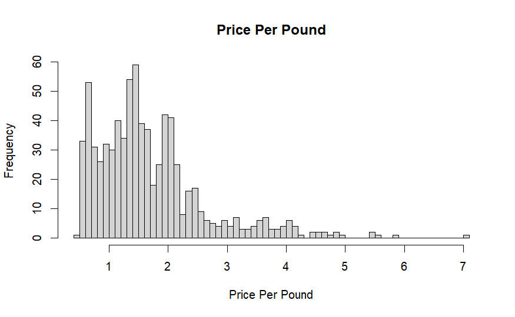

```r
# A better, quick and dirty histogram
hist(HoneyBees$priceperlb, main = "Price Per Pound", xlab = "Price Per Pound", breaks = 55)
```

```r
# Determine where Neonic levels appear more than once
HoneyBees %>%
  group_by(nAllNeonic,) %>% # Make each level its own group
  count(nAllNeonic) %>%  # Count the level in each group
  filter(n > 1) # Only save groups that have more than one level in them
```

| nAllNeonic | n |
| --- | --- |
| 44.5 | 2 |
| 396.8 | 2 |
| 1751.5 | 2 |

```r
HoneyBees %>%
  group_by(year) %>% # Make each numcolony its own group
  mutate(count = n()) %>%  # Count the Year in each group
#  filter(count > 1) %>% # Only save groups that have more than one Year in them
  select(StateName, numcol, nAllNeonic) %>% # Show only the Year and nALLNeonic columns
  arrange(desc (nAllNeonic)) # Arrange by year and then nAllNeonic, for easier viewing
```

| year | StateName | numcol | nAllNeonic |
| --- | --- | --- | --- |
| 2014 | Illinois | 8000 | 403011.6 |
| 2014 | Iowa | 35000 | 375671.1 |
| 2013 | Iowa | 39000 | 335529.9 |
| 2015 | California | 275000 | 334951.8 |
| 2013 | Illinois | 7000 | 333325.6 |
| 2012 | Illinois | 7000 | 309854.0 |
| 2012 | Iowa | 37000 | 276854.7 |
| 2014 | Minnesota | 132000 | 266271.3 |
| 2014 | Indiana | 5000 | 234848.3 |
| 2011 | Illinois | 7000 | 227276.1 |

[output cut: 751 more lines]

I compared the highest levels of all pesticides regardless of the year to the number of colonies.

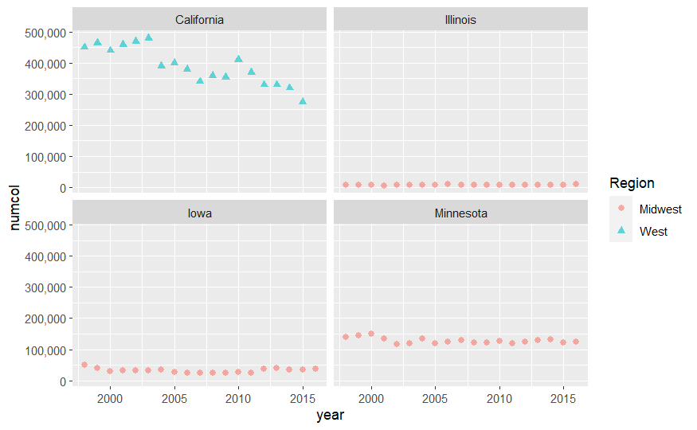

```r
HoneyBees %>%
filter(StateName %in% c("Illinois", "California", "Minnesota", "Iowa")) %>%
ggplot(aes(x = year, y = numcol, shape = Region, color = Region)) +
geom_point(size = 2, alpha = .6) +
scale_y_continuous(labels = scales::comma) +
  facet_wrap(~StateName)
```

```r
#labs(title = "Yields from representative state from each region."
```

# From USDA data

• numcol: Number of honey producing colonies. Honey producing colonies are the maximum number of colonies from which honey was taken during the year. It is possible to take honey from colonies which did not survive the entire year

• yieldpercol: Honey yield per colony. Unit is pounds

• totalprod: Total production (numcol x yieldpercol). Unit is pounds

• stocks: Refers to stocks held by producers. Unit is pounds

• priceperlb: Refers to average price per pound based on expanded sales. Unit is dollars.

• prodvalue: Value of production (totalprod x priceperlb). Unit is dollars.

From USGS Data

• nCLOTHIANIDIN: The amount in kg of CLOTHIANIDIN applied

• nIMIDACLOPRID: The amount in kg of IMIDACLOPRID applied

• nTHIAMETHOXAM: The amount in kg of THIAMETHOXAM applied

• nACETAMIPRID: The amount in kg of ACETAMIPRID applied

• nTHIACLOPRID: The amount in kg of THIACLOPRID applied

• nAllNeonic: The amount in kg of all Neonics applied = (nCLOTHIANIDIN + nIMIDACLOPRID + nTHIAMETHOXAM + nACETAMIPRID + nTHIACLOPRID)